# Predict weight based on height and gender

### Import dataset

```python
import pandas as pd
dataset = pd.read_csv("../Data/weight-height.csv")
```

### Analyze Data

The dataset contains 3 columns namely “Gender”, “Height” and “Weight”.

Height is given in inches and weight in pounds.

### dataset.info():

This method returns the output below. It basically shows the number of entries, the column names and the column types. Below is the output of the command.

```python
dataset.info()
```

```
<class 'pandas.core.frame.DataFrame'>
RangeIndex: 10000 entries, 0 to 9999
Data columns (total 3 columns):
 #   Column  Non-Null Count  Dtype
---  ------  --------------  -----
 0   Gender  10000 non-null  object
 1   Height  10000 non-null  float64
 2   Weight  10000 non-null  float64
dtypes: float64(2), object(1)
memory usage: 234.5+ KB
```

### dataset.describe():

The describe method displays basic statistical information on the numerical values of the dataset like mean, standard deviation, percentile, min and max.

```python
dataset.describe()
```

|  | Height | Weight |
| --- | --- | --- |
| count | 10000.000000 | 10000.000000 |
| mean | 66.367560 | 161.440357 |
| std | 3.847528 | 32.108439 |
| min | 54.263133 | 64.700127 |
| 25% | 63.505620 | 135.818051 |
| 50% | 66.318070 | 161.212928 |
| 75% | 69.174262 | 187.169525 |
| max | 78.998742 | 269.989699 |

### dataset.isnull().sum()

This method is basically used to check if there are any null values in the dataset. This will list number of null values in each column

```python
dataset.isnull().sum()
```

```
Gender    0
Height    0
Weight    0
dtype: int64
```

### Convert Gender to number

Before we run any machine learning models, we have to convert all categorical values (text values) to numerical values. In our dataset, we can see that we have one field — “Gender” which is categorical. So we have to convert this field into numerical.

The typical way of converting `categorical` values to `numerical` is by using the `LabelEncoder` class to convert Text to Numbers and then using OneHotEncoder to add dummy variables.

But this is useful only if the `categorical` field contains `more than 2` values — for instance, let’s say we have a field called “City” and it contains more than 2 values like “Houston”, “New York” and “San Francisco”.

In this case, we will first use LabelEncoder to convert the cities to numbers like: “Houston” => 0 and “New York” => 1 and “San Francisco” => 2.

Then we will use `OneHotEncoder` to add 3 dummy variables one for each city. Finally, we will drop one dummy variable to avoid the dummy variable trap.

```
`The rule of thumb is — if a categorical field has k values then you will need k-1 dummy variables.`
```

Now in our case, our “Gender” field contains only 2 values — “Male” and “Female”. When we use LabelEncoder, it will convert say “Male” =>0 and “Female” => 1. Since it contains only 2 values, there is no need for us to use OneHotEncoder and add dummy variables. If we use OneHotEncoder, it will end up adding 2 dummy variables but we will end up dropping 1 to avoid the dummy trap. So it makes no sense to do it.

So if a categorical field has 2 values — there are 2 ways for us to do this.

### Use LabelEncoder

```python
X = dataset.iloc[:, :-1].values
y = dataset.iloc[:, 2].values
from sklearn.preprocessing import LabelEncoder
labelEncoder_gender =  LabelEncoder()
X[:,0] = labelEncoder_gender.fit_transform(X[:,0])

# Optional - if you want to convert X to float data type
import numpy as np
X = np.vstack(X[:, :]).astype(np.float)
```

```python
dataset.head()
```

|  | Gender | Height | Weight |
| --- | --- | --- | --- |
| 0 | Male | 73.847017 | 241.893563 |
| 1 | Male | 68.781904 | 162.310473 |
| 2 | Male | 74.110105 | 212.740856 |
| 3 | Male | 71.730978 | 220.042470 |
| 4 | Male | 69.881796 | 206.349801 |

### Replace directly in DataFrame

```python
dataset['Gender'].replace('Female',0, inplace=True)
dataset['Gender'].replace('Male',1, inplace=True)
X = dataset.iloc[:, :-1].values
y = dataset.iloc[:, 2].values
```

```python
dataset.head()
```

|  | Gender | Height | Weight |
| --- | --- | --- | --- |
| 0 | 1 | 73.847017 | 241.893563 |
| 1 | 1 | 68.781904 | 162.310473 |
| 2 | 1 | 74.110105 | 212.740856 |
| 3 | 1 | 71.730978 | 220.042470 |
| 4 | 1 | 69.881796 | 206.349801 |

```python
y
```

```
array([241.89356318, 162.31047252, 212.74085556, ..., 128.47531878,
       163.85246135, 113.64910268])
```

```python
dataset.shape
```

```
(10000, 3)
```

### Split dataset into training set and test set

```python
from sklearn.model_selection import train_test_split
X_train, X_test, y_train, y_test = train_test_split(X, y, test_size=0.2, random_state=0)
```

```python
len(X_train)
```

```
8000
```

```python
len(X_test)
```

```
2000
```

### Fit Regression Model

```python
from sklearn.linear_model import LinearRegression
lin_reg = LinearRegression()
lin_reg.fit(X_train, y_train)
```

```
LinearRegression(copy_X=True, fit_intercept=True, n_jobs=None, normalize=False)
```

#### Predict test set values

```python
lin_pred = lin_reg.predict(X_test)
```

### Model Accuracy

```python
from sklearn.metrics import r2_score, mean_absolute_error,mean_squared_error
print(r2_score(y_test,lin_pred))
print(mean_absolute_error(y_test,lin_pred))
print(mean_squared_error(y_test,lin_pred))
```

```
0.9052889824534557
7.955916525326744
97.87152220196162
```

```python
df = pd.DataFrame({'Actual': y_test.flatten(), 'Predicted': lin_pred.flatten()})
df
```

|  | Actual | Predicted |
| --- | --- | --- |
| 0 | 138.085796 | 141.938288 |
| 1 | 187.363366 | 176.556588 |
| 2 | 216.533191 | 219.778362 |
| 3 | 131.761443 | 148.831884 |
| 4 | 157.718438 | 162.092076 |
| ... | ... | ... |
| 1995 | 189.856786 | 187.365166 |
| 1996 | 202.906859 | 203.915748 |
| 1997 | 152.420031 | 149.971296 |
| 1998 | 170.100647 | 166.833749 |
| 1999 | 158.206206 | 138.879407 |

2000 rows × 2 columns

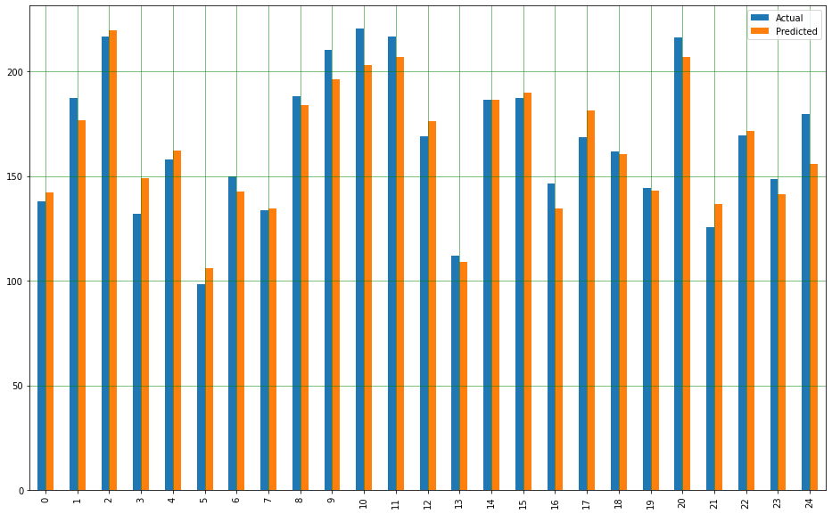

```python
from matplotlib import pyplot as plt
%matplotlib inline
df1 = df.head(25)
df1.plot(kind='bar',figsize=(16,10))
plt.grid(which='major', linestyle='-', linewidth='0.5', color='green')
plt.grid(which='minor', linestyle=':', linewidth='0.5', color='black')
plt.show()
```

```python
X_New = [[ 1., 73.84]]
lin_reg.predict(X_New)
```

```
array([215.71799113])
```